# practical_exercise_2, Methods 3, 2021, autumn semester

Sara Viuf

22-09-2021

# Assignment 1: Using mixed effects modelling to model hierarchical data

In this assignment we will be investigating the *politeness* dataset of Winter and Grawunder (2012) and apply basic methods of multilevel modelling.

## Dataset

The dataset has been shared on GitHub, so make sure that the csv-file is on your current path. Otherwise you can supply the full path.

```r
df <- read.csv('politeness.csv')
```

# Exercises and objectives

The objectives of the exercises of this assignment are:  
1) Learning to recognize hierarchical structures within datasets and describing them  
2) Creating simple multilevel models and assessing their fitness  
3) Write up a report about the findings of the study

REMEMBER: In your report, make sure to include code that can reproduce the answers requested in the exercises below  
REMEMBER: This assignment will be part of your final portfolio

## Exercise 1 - describing the dataset and making some initial plots

1. Describe the dataset, such that someone who happened upon this dataset could understand the variables and what they contain

```r
head(df)
```

```
##   subject gender scenario attitude total_duration  f0mn hiss_count
## 1      F1      F        1      pol         18.392 214.6          2
## 2      F1      F        1      inf         13.551 210.9          0
## 3      F1      F        2      pol          5.217 284.7          0
## 4      F1      F        2      inf          4.247 265.6          0
## 5      F1      F        3      pol          6.791 210.6          0
## 6      F1      F        3      inf          4.126 285.6          0
```

```r
str(df)
```

```
## 'data.frame':    224 obs. of  7 variables:
##  $ subject       : chr  "F1" "F1" "F1" "F1" ...
##  $ gender        : chr  "F" "F" "F" "F" ...
##  $ scenario      : int  1 1 2 2 3 3 4 4 5 5 ...
##  $ attitude      : chr  "pol" "inf" "pol" "inf" ...
##  $ total_duration: num  18.39 13.55 5.22 4.25 6.79 ...
##  $ f0mn          : num  215 211 285 266 211 ...
##  $ hiss_count    : int  2 0 0 0 0 0 1 0 1 0 ...
```

```r
colnames(df)
```

```
## [1] "subject"        "gender"         "scenario"       "attitude"
## [5] "total_duration" "f0mn"           "hiss_count"
```

```r
df$subject <- as.factor(df$subject)
df$gender <- as.factor(df$gender)
df$attitude <- as.factor(df$attitude)
#Subject, contain gender (F/M) and a number
#Gender, F/M
#Scenario, there are 7 scenarios¨
#Attitude, either informal or polite
#total duration, in seconds
#f0mn, fundamental frequency
#hiss_count, not used in any of the models.
```

````
i. Also consider whether any of the variables in _politeness_ should be encoded as factors or have the factor encoding removed. Hint: ```?factor```
````

2. Create a new data frame that just contains the subject *F1* and run two linear models; one that expresses *f0mn* as dependent on *scenario* as an integer; and one that expresses *f0mn* as dependent on *scenario* encoded as a factor

```r
F1 <- subset(df, subject == "F1")

F1$scenario <- as.integer(F1$scenario)
m1 <- lm(f0mn~scenario, F1)
F1$scenario <- as.factor(F1$scenario)
m2 <- lm(f0mn~scenario, F1)
```

```
i. Include the model matrices, $X$ from the General Linear Model, for these two models in your report and describe the different interpretations of _scenario_ that these entail
```

```r
X_m1 <- model.matrix(m1) #scenario is an integer, the model makes it look like there are only two scenarios, when there really are seven. The slope is just an average of all seven scenarios.
X_m2 <- model.matrix(m2) #scenario as a factor, the model shows estimates for all scenarios, which makes it possible to see where an effect is coming from.
```

```
ii. Which coding of _scenario_, as a factor or not, is more fitting?
```

```r
#I think it makes most sense to code scenario as a factor, because there are 7, and not just 2, in which case 2 would be enough
```

3. Make a plot that includes a subplot for each subject that has *scenario* on the x-axis and *f0mn* on the y-axis and where points are colour coded according to *attitude*

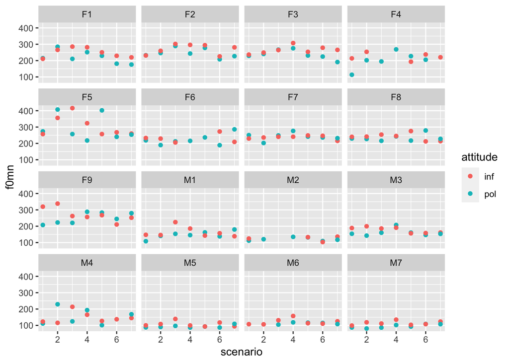

```
i. Describe the differences between subjects
```

```r
ggplot(df, aes(scenario, f0mn, col = attitude)) +facet_wrap(~subject) + geom_point()
```

```r
#In generel as expected the males' intercepts are lower. They seem a bit more consistent in pitch, with less variation. Overgeneralizing obviously.
```

## Exercise 2 - comparison of models

1. Build four models and do some comparisons
   1. a single level model that models *f0mn* as dependent on *gender*

```r
df$scenario <- as.factor(df$scenario)
mix_m1 <- lm(f0mn~gender,df)
```

```
ii. a two-level model that adds a second level on top of i. where unique intercepts are modelled for each _scenario_
```

```r
mix_m2 <- lmer(f0mn~gender+(1|scenario), df)
```

```
iii. a two-level model that only has _subject_ as an intercept
```

```r
mix_m3 <- lmer(f0mn~gender+(1|subject), df)
```

```
iv. a two-level model that models intercepts for both _scenario_ and _subject_
```

```r
mix_m4 <- lmer(f0mn~gender + (1|scenario) + (1|subject), df)
```

```
v. which of the models has the lowest residual standard deviation, also compare the Akaike Information Criterion `AIC`?
```

```r
deviance(mix_m1) #crazy high! Super bad model
```

```
## [1] 327033.6
```

```r
deviance(mix_m2)
```

```
## [1] 2144.314
```

```r
deviance(mix_m3)
```

```
## [1] 2091.626
```

```r
deviance(mix_m4) # has the lowest rss, residual sum of squares. The more layers the lower rss.
```

```
## [1] 2082.482
```

```r
AIC(mix_m1,mix_m2,mix_m3,mix_m4) #Here the model with more layers also has the lowest AIC.
```

```
##        df      AIC
## mix_m1  3 2163.971
## mix_m2  4 2152.314
## mix_m3  4 2099.626
## mix_m4  5 2092.482
```

```
vi. which of the second-level effects explains the most variance?
```

```r
MuMIn::r.squaredGLMM(mix_m2)
```

```
##            R2m       R2c
## [1,] 0.6779555 0.6967788
```

```r
MuMIn::r.squaredGLMM(mix_m3)
```

```
##            R2m       R2c
## [1,] 0.6681651 0.7899229
```

```r
MuMIn::r.squaredGLMM(mix_m4)
```

```
##            R2m       R2c
## [1,] 0.6677206 0.8077964
```

```r
# mix_m4 explains the most variance, lmer(f0mn~gender + (1|scenario) + (1|subject), df) Though it only explains 2% more than mix_m3, which only has random intercepts for subject, and not both.
```

2. Why is our single-level model bad?

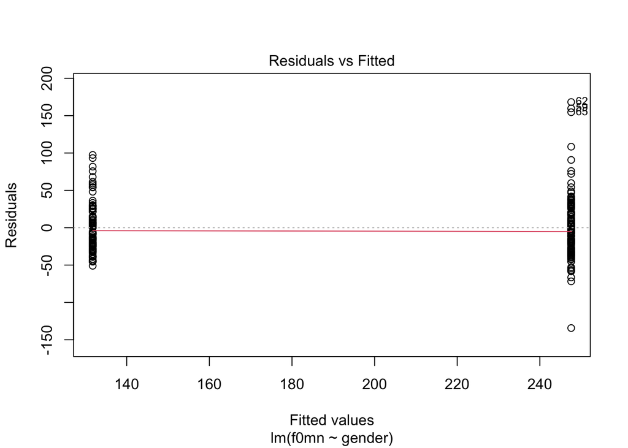

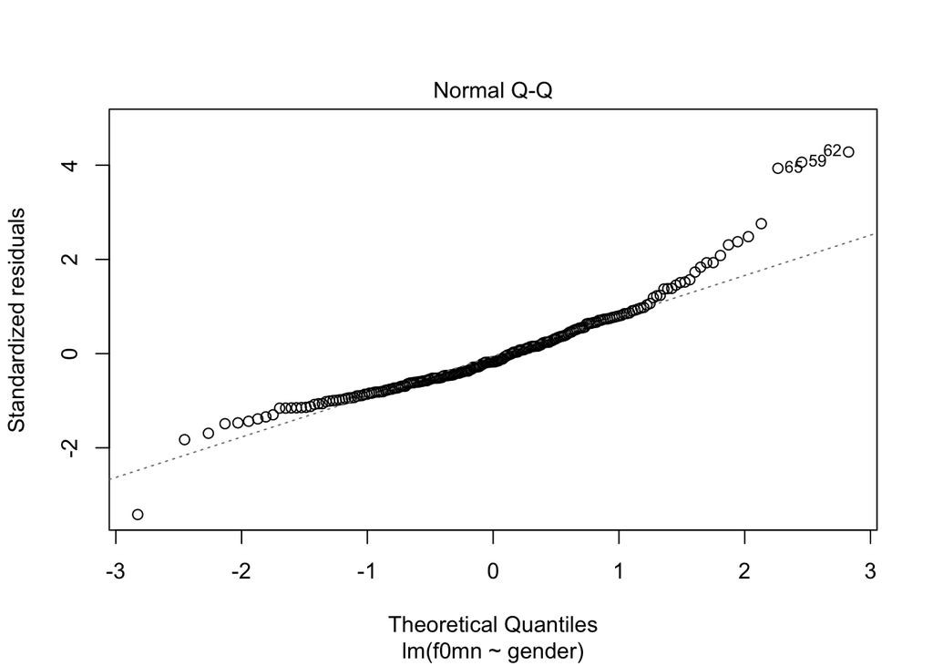

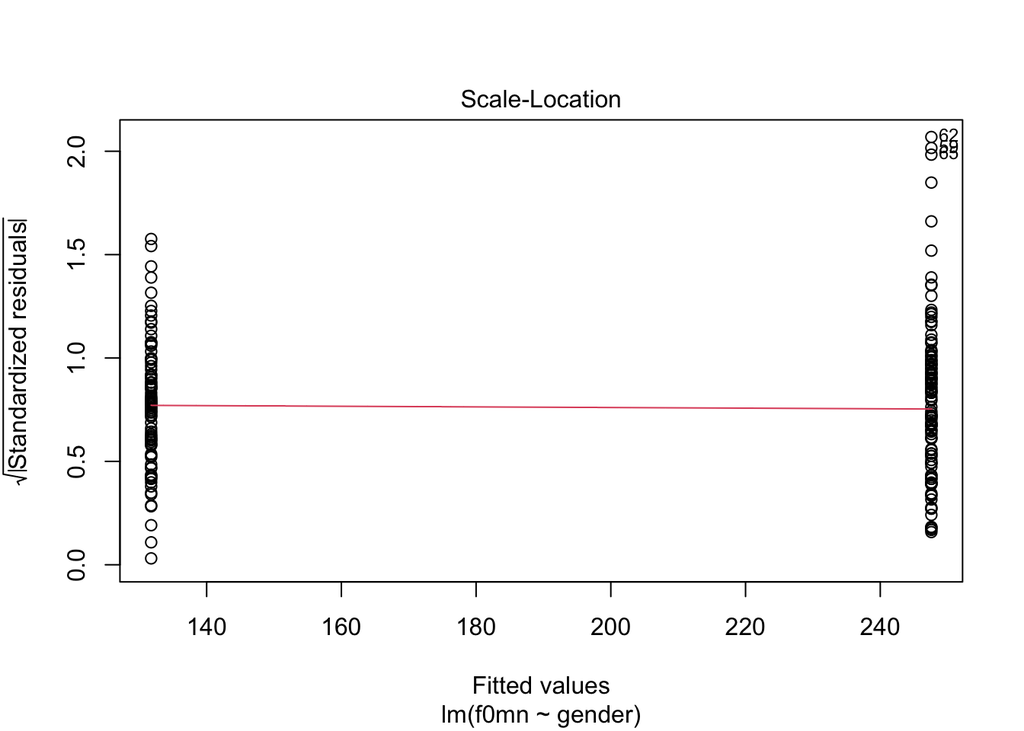

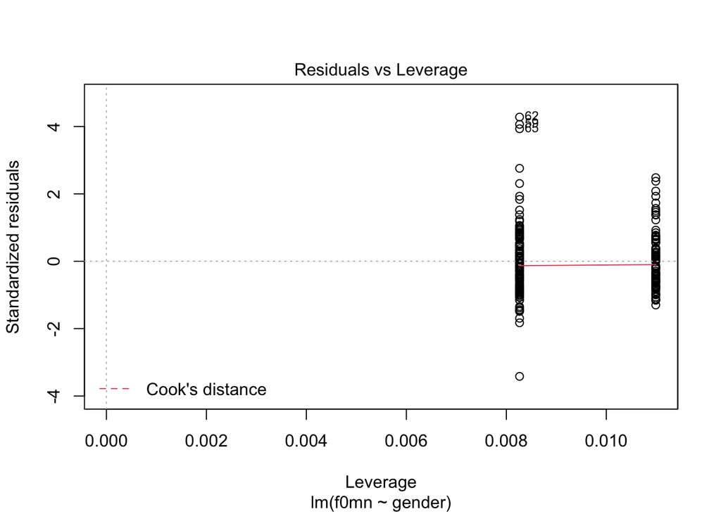

```
i. create a new data frame that has three variables, _subject_, _gender_ and _f0mn_, where _f0mn_ is the average of all responses of each subject, i.e. averaging across _attitude_ and_scenario_
```

```r
#Apparently there is a lot of variance that stems from scenarios and subjects, that when ignored make the model super unstable. Using one binary predictor seems too reductive anyway.
plot(mix_m1)
```

```r
#Adding average
df2 <- df%>%
  group_by(subject) %>%
  summarise_at(vars(f0mn),
               list(mean = mean),na.rm=T)

#Data frame damage control
df <- cbind(df,df2)
names(df)[8] <- "sub"

df2 <- df %>%
  select(subject,gender,mean,sub)

df2$subject <- as.factor(df2$subject)
df2$sub <- as.factor(df2$sub)
```

```
ii. build a single-level model that models _f0mn_ as dependent on _gender_ using this new dataset
```

```r
m3 <- lm(mean~gender,df2)
```

[output not shown]

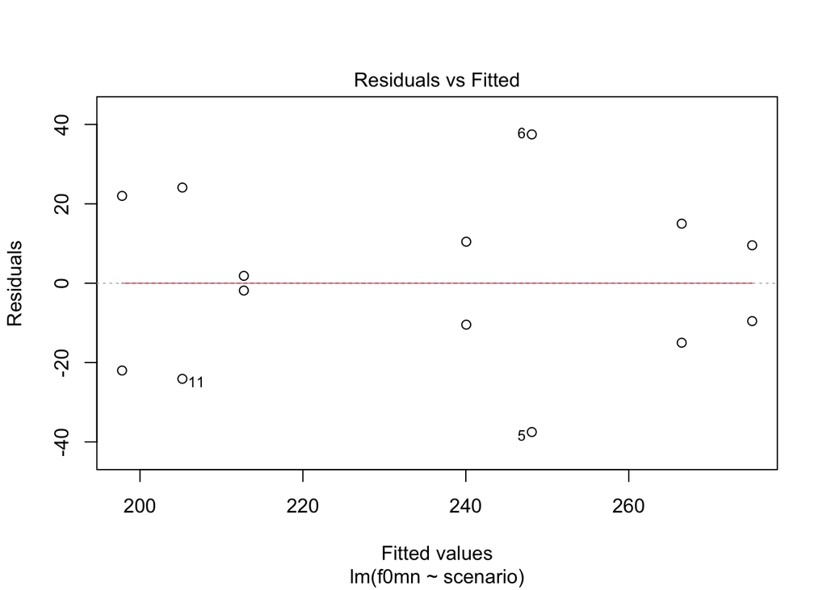

```r
plot(m2,1) #This model fulfills the assumptions of normal distribution of residuals better.
```

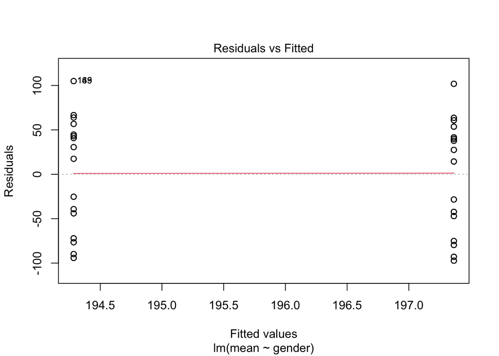

```
iv. Also make a quantile-quantile plot for the residuals of the  multilevel model with two intercepts. Does it look alright?
```

```r
plot(m3,1) #This model literally had a negative Rsquared, -0.003895
```

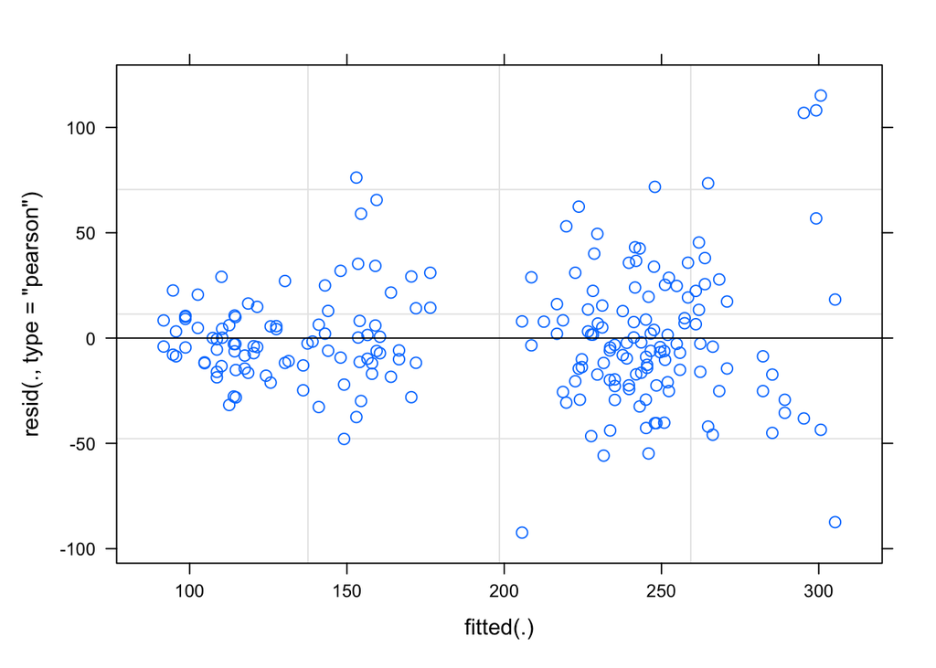

```r
plot(mix_m4) #Looks fine. The apparent grouping is due to gender.
```

3. Plotting the two-intercepts model
   1. Create a plot for each subject, (similar to part 3 in Exercise 1), this time also indicating the fitted value for each of the subjects for each for the scenarios (hint use `fixef` to get the “grand effects” for each gender and `ranef` to get the subject- and scenario-specific effects)

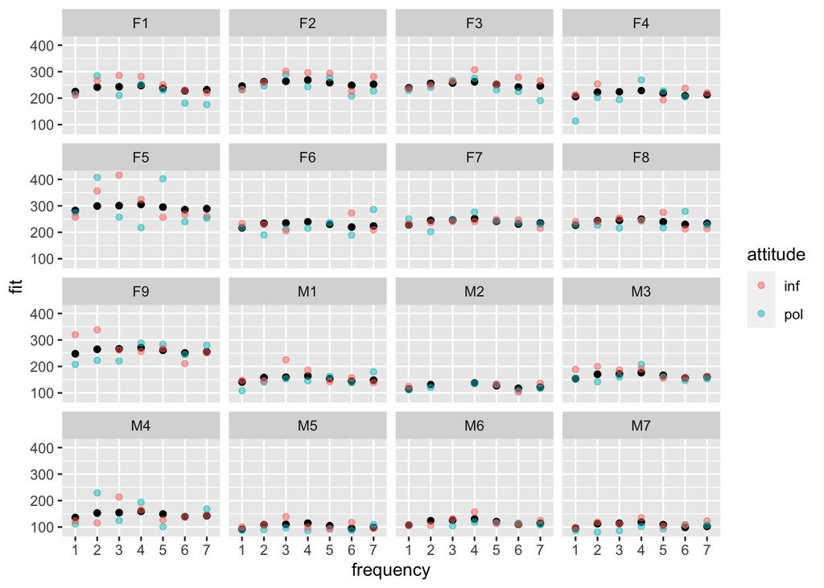

```r
fit <- fitted.values(mix_m4)
df <- subset(df, f0mn != " ")
df <- cbind(df,fit)

ggplot(df) + facet_wrap(~subject) + geom_point(aes(scenario, fit)) + geom_point(aes(scenario, f0mn, color = attitude), alpha = 0.5) + xlab("frequency") # the black point represent the fitted value for the model mix_m4, the values the model predicts.
```

## Exercise 3 - now with attitude